# Babies - Study 2 - Results

This is hopefully the results section for the Study 2 NSE & SE babies watching ASL Stories. We have two main factors:

1. Language (Sign v. English)
2. Direction (Forward v. Reversed)

Ages of babies are from 5 to 14.99 months. That means we lose two “old” CODA babies - Janine (16 mo) and za02 (23 mo). The dataset also contains factors for younger v. older babies *IF* we want to do age group splits. I do not recommend it because we lose all significance that way and we have more precise age information, better than brute groups. IF we do use it, the baby age groups are such:

- Younger babies = 5 to 8.99 months
- Older babies = 9.0 to 14.99 months

# Demographics

```r
library(tidyverse)
library(janitor)
library(lme4)
library(lmerTest)
library(scales)
library(feather)
library(GGally)

# Grab data that was produced in 03importcleanbabies.Rmd
babies <- read_feather("cleanedbabyeyedata.feather") %>%
  mutate(age = age*12) %>%
  select(participant, language, age, gender, story, direction, mark, trial, repetition, aoi, secs, percent) %>%
  rename(name = participant) %>%
  mutate(agegroup = case_when(
    age <= 8.99 ~ "younger",
    age >= 9.0 & age < 15 ~ "older"
  )) %>%
  filter(!is.na(agegroup)) %>%
  mutate(language = case_when(
    language == "english" ~ "NSE",
    language =="sign" ~ "SE"
  )) %>%
  rename(lang = language) %>%
  mutate(lang2 = case_when(
    name == "aubrey CODA 11m" ~ "HSE",
    name == "GemmaF_11_4_13_CODA" ~ "HSE",
    name == "Hannah_CODA_7m" ~ "HSE",
    name == "ke11es12_7m_MomTerp" ~ "LSE",
    name == "Miles_14m_SE" ~ "HSE",
    name == "Parker 6 m SIGNING" ~ "HSE",
    name == "Penn 6 months SIGN EXPOSED" ~ "HSE",
    name == "Trinity 8m" ~ "LSE",
    name == "Victoria07_18_17" ~ "LSE",
    name == "Wells_8mos" ~ "LSE",
    TRUE ~ lang
  ))
#  filter(name != "Victoria07_18_17")

babiesinfo <- babies %>%
  select(name, lang, age, gender) %>%
  distinct() %>%
  group_by(lang) %>%
  summarise(N = n(),
            age_mean = mean(age),
            sd = sd(age),
            min = min(age),
            max = max(age))

genders <- babies %>%
  select(name, lang, age, gender) %>%
  distinct() %>%
  group_by(lang, gender) %>%
  summarise(N = n()) %>%
  spread(gender, N)

babiesinfo <- left_join(babiesinfo, genders) %>%
  select(lang, N, Female, Male, age_mean, sd, min, max) %>%
  print()
```

| lang | N | Female | Male | age_mean | sd | min | max |
| --- | --- | --- | --- | --- | --- | --- | --- |
| NSE | 16 | 5 | 11 | 8.265 | 2.888280 | 5.28 | 13.2 |
| SE | 10 | 7 | 3 | 9.312 | 2.642544 | 6.96 | 14.4 |

```r
babies$agegroup <- fct_relevel(babies$agegroup, c("younger","older"))

# t-test for NSE v. SE ages
summary(lm(data = distinct(select(babies, age, lang)), age ~ lang))
```

```
Call:
lm(formula = age ~ lang, data = distinct(select(babies, age,
    lang)))

Residuals:
   Min     1Q Median     3Q    Max
-3.103 -2.206 -1.456  2.624  5.324

Coefficients:
            Estimate Std. Error t value Pr(>|t|)
(Intercept)   7.8764     0.8774   8.977 1.21e-07 ***
langSE        2.1865     1.4070   1.554     0.14
---
Signif. codes:  0 ‘***’ 0.001 ‘**’ 0.01 ‘*’ 0.05 ‘.’ 0.1 ‘ ’ 1

Residual standard error: 2.91 on 16 degrees of freedom
Multiple R-squared:  0.1311,    Adjusted R-squared:  0.07684
F-statistic: 2.415 on 1 and 16 DF,  p-value: 0.1397
```

```r
# IF we do age groups, use this code
#
# babiesinfo <- babies %>%
#   select(name, lang, age, agegroup, gender) %>%
#   distinct() %>%
#   group_by(lang, agegroup) %>%
#   summarise(N = n(),
#             age_mean = mean(age),
#             sd = sd(age),
#             min = min(age),
#             max = max(age))
#
# genders <- babies %>%
#   select(name, lang, age, agegroup, gender) %>%
#   distinct() %>%
#   group_by(lang, agegroup, gender) %>%
#   summarise(N = n()) %>%
#   spread(gender, N)
#
# babiesinfo <- left_join(babiesinfo, genders) %>%
#   select(lang, agegroup, N, Female, Male, age_mean, sd, min, max) %>%
#   print()
```

# Global Looking

We calculated percentages *based on overall clip length* as the denominator. In this way, we can meaningfully contrast looking times at the videos (which are variable lengths) based on different factors. But when we go to AOI analysis we need to re-calculate the percentages so the denominator is based on total looking time, not overall clip length.

The chart below shows little differences based on factors Age, Language, or Direction. That’s good, means the videos were equally engaging for all babies, right?

```r
babies$lang <- as.factor(babies$lang)
babies_overall_looking <- babies %>%
  group_by(name, age, lang, direction, story, trial) %>%
  summarise(percent = sum(percent)) # gets total looking percent for each trial for each baby

# Table of means
babies_overall_looking %>%
  group_by(name, lang, direction) %>%
  summarise(percent = mean(percent)) %>% # get average looking percent for each baby
  group_by(lang, direction) %>%
  summarise(mean_percent = mean(percent),
            count = n(),
            sd = sd(percent),
            se = sd/sqrt(count)) %>%
  select(-sd) %>%
  print()
```

| lang | direction | mean_percent | count | se |
| --- | --- | --- | --- | --- |
| NSE | forward | 0.6939423 | 16 | 0.03008907 |
| NSE | reversed | 0.6605881 | 16 | 0.04104712 |
| SE | forward | 0.6479070 | 10 | 0.02951300 |
| SE | reversed | 0.6392419 | 10 | 0.03616704 |

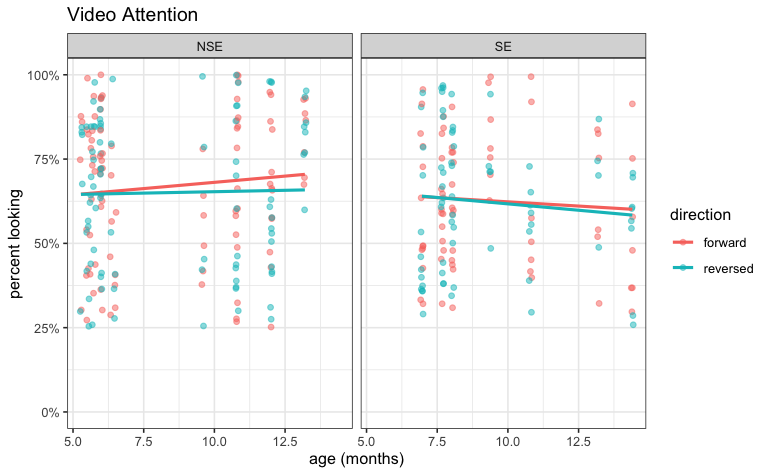

```r
ggplot(babies_overall_looking, aes(x = age, y = percent, color = direction, fill = direction)) +
  geom_jitter(alpha = 0.5) +
  facet_grid(. ~ lang) +
  geom_smooth(method = "lm", se = FALSE) +
  ggtitle("Video Attention") +
  xlab("age (months)") +
  ylab("percent looking") +
  theme_bw() +
  scale_y_continuous(limits = c(0,1), labels = percent)
```

```r
# Plot
# babies_overall_looking %>%
#   group_by(lang, direction, name) %>%
#   summarise(percent = mean(percent)) %>% # gets average looking percent for each baby
#   group_by(lang, direction) %>%
#   summarise(mean_percent = mean(percent), # gets group averages
#             count = n(),
#             sd = sd(percent),
#             se = sd/sqrt(count)) %>%
#   ggplot(aes(x = lang, y = mean_percent, fill = direction)) +
#   geom_col(position = "dodge") +
#   geom_errorbar(aes(ymin = mean_percent - se, ymax = mean_percent + se),
#                 position = position_dodge(width = 0.9), width = 0.25) +
#   scale_y_continuous(limits = c(0,1), labels = percent) +
#   theme_minimal() +
#   theme(panel.grid.major.x = element_blank()) +
# #  facet_wrap("lang") +
#   ggtitle("Video Attention") +
#   xlab("") +
#   ylab("percent looking")

# babies_overall_looking %>%
#   ggplot(aes(x = lang, y = percent, fill = direction)) +
#   facet_wrap("agegroup") +
#   geom_violin()
```

A linear model shows there were no significant effects of any factors except for Trial order. We can conclude there was no effect found for age or language experience on how *much* the babies looked at the stimuli.

```r
global_lm <- lmer(percent ~ age + lang * direction + trial + (1|name) + (1|story), data = babies_overall_looking)
summary(global_lm)
```

```
Linear mixed model fit by REML. t-tests use Satterthwaite's method [
lmerModLmerTest]
Formula: percent ~ age + lang * direction + trial + (1 | name) + (1 |
    story)
   Data: babies_overall_looking

REML criterion at convergence: -113.7

Scaled residuals:
     Min       1Q   Median       3Q      Max
-2.32953 -0.67242  0.00036  0.67085  3.00310

Random effects:
 Groups   Name        Variance Std.Dev.
 name     (Intercept) 0.013938 0.1181
 story    (Intercept) 0.004516 0.0672
 Residual             0.032169 0.1794
Number of obs: 349, groups:  name, 26; story, 8

Fixed effects:
                           Estimate Std. Error         df t value Pr(>|t|)
(Intercept)                0.767286   0.089491  28.873683   8.574 1.99e-09
age                        0.001069   0.009330  22.518540   0.115    0.910
langSE                    -0.047104   0.055786  28.748730  -0.844    0.405
directionreversed         -0.025388   0.025399 315.431461  -1.000    0.318
trial                     -0.010551   0.002290 321.773991  -4.607 5.90e-06
langSE:directionreversed   0.023757   0.039347 314.560047   0.604    0.546

(Intercept)              ***
age
langSE
directionreversed
trial                    ***
langSE:directionreversed
---
Signif. codes:  0 ‘***’ 0.001 ‘**’ 0.01 ‘*’ 0.05 ‘.’ 0.1 ‘ ’ 1

Correlation of Fixed Effects:
            (Intr) age    langSE drctnr trial
age         -0.862
langSE      -0.088 -0.172
dirctnrvrsd -0.125 -0.001  0.217
trial       -0.189 -0.009 -0.001 -0.045
lngSE:drctn  0.091  0.007 -0.342 -0.643 -0.048
```

```r
confint(global_lm)
```

```
Computing profile confidence intervals ...
```

```
                               2.5 %       97.5 %
.sig01                    0.08026528  0.156657941
.sig02                    0.03619562  0.122831477
.sigma                    0.16547500  0.193444895
(Intercept)               0.59530636  0.939325590
age                      -0.01695290  0.019083554
langSE                   -0.15450968  0.060410603
directionreversed        -0.07499687  0.024407312
trial                    -0.01502580 -0.006058211
langSE:directionreversed -0.05331980  0.100699729
```

```r
#ggcoef(global_lm)

library(sjPlot)
library(sjmisc)
library(sjlabelled)

tab_model(global_lm, show.se = T, show.stat = T)
```

# AOI Looking

Now we’ll re-calculate the percentages so the denominator is based on total looking time. All AOIs should sum up to 100% for each trial and each baby. Next let’s make a boxplot of all AOIs.

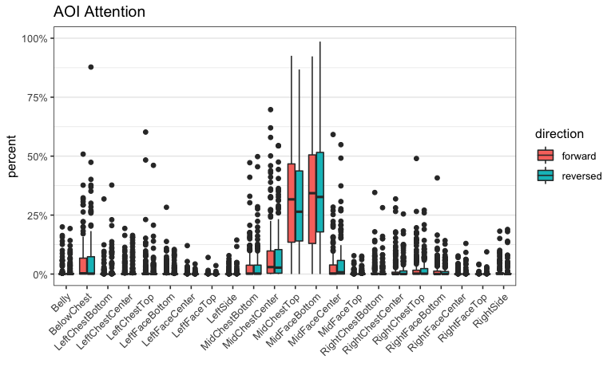

```r
#Recalculate percent
babies <- babies %>%
  ungroup() %>%
  select(-percent) %>%
  group_by(name, lang, agegroup, age, direction, story, mark, trial, repetition, gender) %>%
  mutate(totalsec = sum(secs)) %>%
  group_by(name, lang, agegroup, age, direction, story, mark, trial, repetition, gender, aoi) %>%
  mutate(percent = secs/totalsec)

# Boxplot
babies %>%
  ggplot(aes(x = aoi, y = percent, fill = direction)) +
  geom_boxplot() +
  ggtitle("AOI Attention") +
  theme_bw() +
  xlab("") +
  theme(axis.text.x = element_text(angle=45, hjust = 1),
        panel.grid.major.x = element_blank()) +
  scale_y_continuous(labels = scales::percent, limits = c(0,1))
```

It appears two important AOIs are MidChestTop and MidFaceBottom. Let’s look again only at midline AOIs:

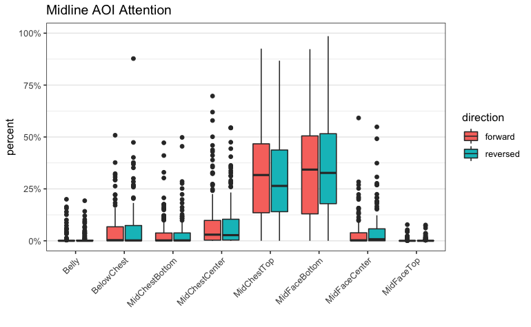

```r
midline = c("Belly","BelowChest","MidChestBottom","MidChestCenter","MidChestTop",
            "MidFaceBottom","MidFaceCenter","MidFaceTop")
babies %>%
  filter(aoi %in% midline) %>%
  ggplot(aes(x = aoi, y = percent, fill = direction)) +
  geom_boxplot() +
  ggtitle("Midline AOI Attention") +
  theme_bw() +
  xlab("") +
  theme(axis.text.x = element_text(angle=45, hjust = 1),
        panel.grid.major.x = element_blank()) +
  scale_y_continuous(labels = scales::percent, limits = c(0,1))
```

I’m going to run linear models with only MidChestTop or MidFaceBottom, and see what happens. No age interactions.

**MidFaceBottom:**

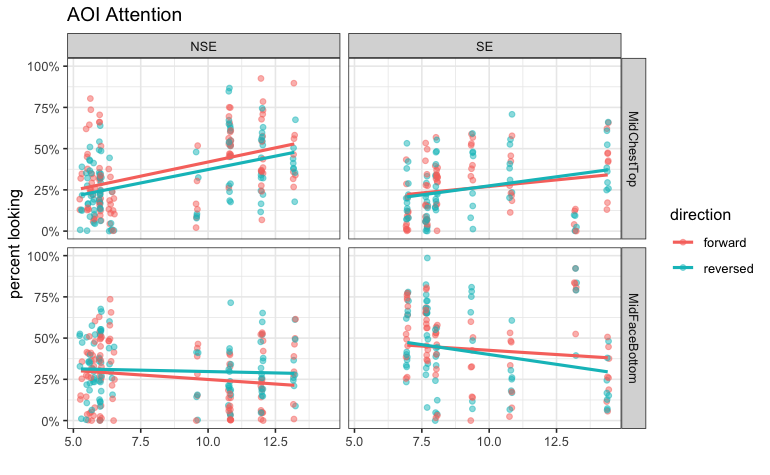

```r
babies %>%
  filter(aoi %in% c("MidFaceBottom","MidChestTop")) %>%
  ggplot(aes(x = age, y = percent, color = direction, fill = direction)) +
  geom_jitter(alpha = 0.5) +
  geom_smooth(method = "lm", se = FALSE) +
  scale_y_continuous(limits = c(0,1), labels = percent) +
  theme_bw() +
#  theme(panel.grid.major.x = element_blank()) +
  facet_grid(aoi ~ lang) +
  ggtitle("AOI Attention") +
  xlab("") +
  ylab("percent looking")
```

```r
midchesttop_lm <- lmer(percent ~ age + lang * direction + (1|name) + (1|story), data = filter(babies, aoi == "MidChestTop"))
summary(midchesttop_lm)
```

```
Linear mixed model fit by REML. t-tests use Satterthwaite's method [
lmerModLmerTest]
Formula: percent ~ age + lang * direction + (1 | name) + (1 | story)
   Data: filter(babies, aoi == "MidChestTop")

REML criterion at convergence: -215.1

Scaled residuals:
    Min      1Q  Median      3Q     Max
-3.0298 -0.7175 -0.1352  0.6298  2.6697

Random effects:
 Groups   Name        Variance  Std.Dev.
 name     (Intercept) 0.0115078 0.1073
 story    (Intercept) 0.0002281 0.0151
 Residual             0.0253723 0.1593
Number of obs: 349, groups:  name, 26; story, 8

Fixed effects:
                           Estimate Std. Error         df t value Pr(>|t|)
(Intercept)                0.123866   0.076757  23.371972   1.614  0.12001
age                        0.028038   0.008448  22.005650   3.319  0.00312
langSE                    -0.132994   0.050397  27.850283  -2.639  0.01346
directionreversed         -0.044820   0.022405 320.419630  -2.000  0.04629
langSE:directionreversed   0.039943   0.034787 318.190116   1.148  0.25175

(Intercept)
age                      **
langSE                   *
directionreversed        *
langSE:directionreversed
---
Signif. codes:  0 ‘***’ 0.001 ‘**’ 0.01 ‘*’ 0.05 ‘.’ 0.1 ‘ ’ 1

Correlation of Fixed Effects:
            (Intr) age    langSE drctnr
age         -0.912
langSE      -0.092 -0.172
dirctnrvrsd -0.139 -0.001  0.213
lngSE:drctn  0.085  0.006 -0.336 -0.644
```

```r
confint(midchesttop_lm)
```

```
Computing profile confidence intervals ...
```

```
                               2.5 %        97.5 %
.sig01                    0.07183592  0.1408795019
.sig02                    0.00000000  0.0455736684
.sigma                    0.14721089  0.1721220249
(Intercept)              -0.02299300  0.2706422164
age                       0.01187038  0.0442054478
langSE                   -0.22928875 -0.0366528701
directionreversed        -0.08864808 -0.0008204047
langSE:directionreversed -0.02820489  0.1081961718
```

```r
#ggcoef(midchesttop_lm)

midfacebottom_lm <- lmer(percent ~ age + lang * direction + (1|name) + (1|story), data = filter(babies, aoi == "MidFaceBottom"))
summary(midfacebottom_lm)
```

```
Linear mixed model fit by REML. t-tests use Satterthwaite's method [
lmerModLmerTest]
Formula: percent ~ age + lang * direction + (1 | name) + (1 | story)
   Data: filter(babies, aoi == "MidFaceBottom")

REML criterion at convergence: -159.7

Scaled residuals:
     Min       1Q   Median       3Q      Max
-2.42568 -0.76861 -0.01802  0.69751  2.50871

Random effects:
 Groups   Name        Variance Std.Dev.
 name     (Intercept) 0.019840 0.14085
 story    (Intercept) 0.002588 0.05088
 Residual             0.028320 0.16829
Number of obs: 349, groups:  name, 26; story, 8

Fixed effects:
                           Estimate Std. Error         df t value Pr(>|t|)
(Intercept)                0.327355   0.099254  25.201834   3.298   0.0029
age                       -0.008293   0.010813  22.878745  -0.767   0.4510
langSE                     0.193677   0.063358  26.931393   3.057   0.0050
directionreversed          0.038757   0.023800 317.155595   1.628   0.1044
langSE:directionreversed  -0.052648   0.036870 315.966430  -1.428   0.1543

(Intercept)              **
age
langSE                   **
directionreversed
langSE:directionreversed
---
Signif. codes:  0 ‘***’ 0.001 ‘**’ 0.01 ‘*’ 0.05 ‘.’ 0.1 ‘ ’ 1

Correlation of Fixed Effects:
            (Intr) age    langSE drctnr
age         -0.902
langSE      -0.082 -0.176
dirctnrvrsd -0.113 -0.001  0.179
lngSE:drctn  0.069  0.005 -0.283 -0.647
```

```r
confint(midfacebottom_lm)
```

```
Computing profile confidence intervals ...
```

```
                                2.5 %     97.5 %
.sig01                    0.098862423 0.18348410
.sig02                    0.024985536 0.09798262
.sigma                    0.155497012 0.18175853
(Intercept)               0.136571835 0.51798698
age                      -0.029093105 0.01252478
langSE                    0.071974034 0.31548548
directionreversed        -0.007931901 0.08534794
langSE:directionreversed -0.124894091 0.01963867
```

```r
#ggcoef(midfacebottom_lm)

# Bar chart
# babies %>%
#   filter(aoi %in% c("MidFaceBottom","MidChestTop")) %>%
#   group_by(agegroup, lang, direction, name, aoi) %>%
#   summarise(percent = mean(percent)) %>% # gets average looking percent for each baby
#   group_by(agegroup, lang, direction, aoi) %>%
#   summarise(mean_percent = mean(percent), # gets group averages
#             count = n(),
#             sd = sd(percent),
#             se = sd/sqrt(count)) %>%
#   ggplot(aes(x = lang, y = mean_percent, fill = direction)) +
#   geom_col(position = "dodge") +
#   geom_errorbar(aes(ymin = mean_percent - se, ymax = mean_percent + se),
#                 position = position_dodge(width = 0.9), width = 0.25) +
#   scale_y_continuous(limits = c(0,1), labels = percent) +
#   theme_minimal() +
#   theme(panel.grid.major.x = element_blank()) +
#   facet_grid(aoi ~ agegroup) +
#   ggtitle("Video Attention") +
#   xlab("") +
#   ylab("percent looking")
```

# Face-Chest Ratio

Next, we’ll define a Face-Chest Ratio (FCR) such that:

1. MidFaceCenter, MidFaceBottom = Face
2. MidChestTop, MidChestCenter, MidChestBottom, BelowChest = Chest
3. FCR = face - chest / face + chest

We did not include Belly or MidFaceTop because of very low looking rates according to the boxplots above.

```r
babies_fcr <- babies %>%
  ungroup() %>%
  spread(aoi, percent) %>%
  group_by(name, age, agegroup, lang, gender, direction, story, trial) %>%
  summarise(face = sum(MidFaceCenter, MidFaceBottom, na.rm = TRUE),
         chest = sum(MidChestTop, MidChestCenter, MidChestBottom, BelowChest, na.rm = TRUE),
         fcr = (face - chest) / (face + chest))

# Table of means
babies_fcr %>%
  group_by(lang, direction, name) %>%
  summarise(fcr = mean(fcr)) %>% # gets average looking percent for each baby
  group_by(lang, direction) %>%
  summarise(mean_fcr = mean(fcr), # gets group averages
            count = n(),
            sd = sd(fcr),
            se = sd/sqrt(count)) %>%
  select(-sd) %>%
  print()
```

| lang | direction | mean_fcr | count | se |
| --- | --- | --- | --- | --- |
| NSE | forward | -0.30393297 | 16 | 0.08818033 |
| NSE | reversed | -0.16875827 | 16 | 0.07543600 |
| SE | forward | 0.12515253 | 10 | 0.17462489 |
| SE | reversed | 0.09566401 | 10 | 0.16904475 |

```r
babies_fcr %>%
  group_by(lang, name) %>%
  summarise(fcr = mean(fcr)) %>% # gets average looking percent for each baby
  group_by(lang) %>%
  summarise(mean_fcr = mean(fcr), # gets group averages
            count = n(),
            sd = sd(fcr),
            se = sd/sqrt(count)) %>%
  select(-sd) %>%
  print()
```

| lang | mean_fcr | count | se |
| --- | --- | --- | --- |
| NSE | -0.2375495 | 16 | 0.07875006 |
| SE | 0.1100685 | 10 | 0.16621705 |

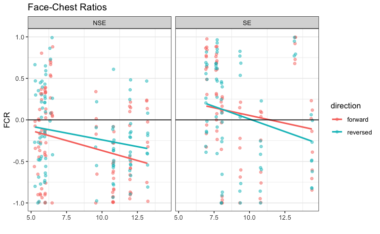

```r
# Plot
ggplot(babies_fcr, aes(x = age, y = fcr, color = direction, fill = direction)) +
  geom_jitter(alpha = 0.5) +
  geom_smooth(method = "lm", se = FALSE) +
  scale_y_continuous(limits = c(-1,1)) +
  geom_hline(yintercept = 0) +
  theme_bw() +
  theme(panel.grid.major.x = element_blank()) +
  facet_grid(. ~ lang) +
  ggtitle("Face-Chest Ratios") +
  xlab("") +
  ylab("FCR")
```

```r
# Bar chart
# babies_fcr %>%
#   group_by(agegroup, lang, direction, name) %>%
#   summarise(fcr = mean(fcr)) %>% # gets average looking percent for each baby
#   group_by(agegroup, lang, direction) %>%
#   summarise(mean_fcr = mean(fcr), # gets group averages
#             count = n(),
#             sd = sd(fcr),
#             se = sd/sqrt(count)) %>%
#   ggplot(aes(x = lang, y = mean_fcr, fill = direction)) +
#   geom_col(position = "dodge") +
#   geom_errorbar(aes(ymin = mean_fcr - se, ymax = mean_fcr + se),
#                 position = position_dodge(width = 0.9), width = 0.25) +
#   scale_y_continuous(limits = c(-1,1)) +
#   theme_minimal() +
#   theme(panel.grid.major.x = element_blank()) +
#   facet_wrap("agegroup") +
#   ggtitle("Face-Chest Ratios") +
#   xlab("") +
#   ylab("FCR")
```

What will a linear mixed model tell us? (with no age interactions)

- No effect of age. Interesting. Maybe because we don’t have that many babies.
- Strong effect of language: SE babies have overall more FCR than NSE babies; in other words, they are more attracted to the face.
- Strong effect of direction: Reversal *increases* FCR across all babies.
- Strong effect of trial: The more trials there are, the more FCR drops (fatigue?) or the more they’re attending to hands
- No language x direction interaction.

```r
fcr_lm <- lmer(fcr ~ age + lang * direction + trial + (1|name) + (1|story), data = babies_fcr)
summary(fcr_lm)
```

```
Linear mixed model fit by REML. t-tests use Satterthwaite's method [
lmerModLmerTest]
Formula: fcr ~ age + lang * direction + trial + (1 | name) + (1 | story)
   Data: babies_fcr

REML criterion at convergence: 435.5

Scaled residuals:
     Min       1Q   Median       3Q      Max
-2.30527 -0.73060  0.06152  0.62206  2.47126

Random effects:
 Groups   Name        Variance Std.Dev.
 name     (Intercept) 0.14493  0.3807
 story    (Intercept) 0.01043  0.1021
 Residual             0.15413  0.3926
Number of obs: 349, groups:  name, 26; story, 8

Fixed effects:
                           Estimate Std. Error         df t value Pr(>|t|)
(Intercept)                0.139805   0.265036  25.260443   0.527  0.60245
age                       -0.039434   0.028862  22.821621  -1.366  0.18516
langSE                     0.452861   0.167538  25.877336   2.703  0.01197
directionreversed          0.123748   0.055557 316.220301   2.227  0.02662
trial                     -0.014716   0.004971 315.117235  -2.960  0.00331
langSE:directionreversed  -0.128642   0.086089 315.102861  -1.494  0.13610

(Intercept)
age
langSE                   *
directionreversed        *
trial                    **
langSE:directionreversed
---
Signif. codes:  0 ‘***’ 0.001 ‘**’ 0.01 ‘*’ 0.05 ‘.’ 0.1 ‘ ’ 1

Correlation of Fixed Effects:
            (Intr) age    langSE drctnr trial
age         -0.900
langSE      -0.077 -0.179
dirctnrvrsd -0.092 -0.001  0.158
trial       -0.138 -0.006  0.000 -0.045
lngSE:drctn  0.067  0.005 -0.249 -0.643 -0.047
```

```r
confint(fcr_lm)
```

```
Computing profile confidence intervals ...
```

```
                               2.5 %       97.5 %
.sig01                    0.26989440  0.492462218
.sig02                    0.04324525  0.204945788
.sigma                    0.36219069  0.423400899
(Intercept)              -0.36865844  0.648440005
age                      -0.09486627  0.016002186
langSE                    0.13152974  0.774370078
directionreversed         0.01489700  0.232329832
trial                    -0.02456749 -0.004973317
langSE:directionreversed -0.29692896  0.040056988
```

```r
tab_model(fcr_lm, show.se = T, show.stat = T)

write_csv(babies_fcr, "fcr_trial_level_values_babies.csv")

# https://jofrhwld.github.io/teaching/courses/2017_lsa/lectures/Session_8.nb.html
# library(boot)
# fcr_boot <- bootMer(fcr_lm, FUN = fixef, nsim = 1000)
# fcr_boot
# boot.ci(fcr_boot, index = 3, type = "perc")

#ggcoef(fcr_lm)

#emmeans::emmeans(fcr_lm, list(pairwise ~ direction*lang), adjust = "none")

# fcrse_lm <- lmer(fcr ~ age + direction + (1|name) + (1|story), data = filter(babies_fcr, lang == "SE"))
# fcrnse_lm <- lmer(fcr ~ age + direction + (1|name) + (1|story), data = filter(babies_fcr, lang == "NSE"))
# summary(fcrse_lm)
# summary(fcrnse_lm)
```

## “Posthoc” for NSE babies only

```r
post_hoc <- lmer(fcr ~ age + direction + trial + (1|name) + (1|story),
                 data = filter(babies_fcr, lang == 'NSE'))
summary(post_hoc)
```

```
Linear mixed model fit by REML. t-tests use Satterthwaite's method [
lmerModLmerTest]
Formula: fcr ~ age + direction + trial + (1 | name) + (1 | story)
   Data: filter(babies_fcr, lang == "NSE")

REML criterion at convergence: 260.4

Scaled residuals:
     Min       1Q   Median       3Q      Max
-2.09911 -0.81552  0.03004  0.66371  2.20414

Random effects:
 Groups   Name        Variance Std.Dev.
 name     (Intercept) 0.07523  0.2743
 story    (Intercept) 0.01057  0.1028
 Residual             0.15969  0.3996
Number of obs: 205, groups:  name, 16; story, 8

Fixed effects:
                    Estimate Std. Error         df t value Pr(>|t|)
(Intercept)         0.161899   0.240350  16.061114   0.674   0.5101
age                -0.043890   0.026423  13.650286  -1.661   0.1195
directionreversed   0.115449   0.056747 184.340481   2.034   0.0433 *
trial              -0.012336   0.006559 184.974895  -1.881   0.0616 .
---
Signif. codes:  0 ‘***’ 0.001 ‘**’ 0.01 ‘*’ 0.05 ‘.’ 0.1 ‘ ’ 1

Correlation of Fixed Effects:
            (Intr) age    drctnr
age         -0.908
dirctnrvrsd -0.100 -0.001
trial       -0.199 -0.012 -0.055
```

```r
confint(post_hoc)
```

```
Computing profile confidence intervals ...
```

```
                         2.5 %       97.5 %
.sig01             0.169715459 0.3978356095
.sig02             0.006467725 0.2171779368
.sigma             0.360019867 0.4424057387
(Intercept)       -0.306473255 0.6320176979
age               -0.095864510 0.0078047449
directionreversed  0.004001765 0.2267683724
trial             -0.025328171 0.0004950939
```

# The Large Table

> I would like a large table with all individual percent looking means for each AOI and the individual FCR values, with ages, gender, video group for each child. (collapsed across stories and trials)

```r
# babies has the AOI info, babies_fcr has FCR
# Collapse across stories and trials

babies_spread <- babies %>%
  group_by(name, lang, age, gender, direction, aoi) %>%
  summarise(percent = mean(percent, na.rm = T)) %>%
  spread(aoi, percent)

babies_fcr_spread <- babies_fcr %>%
  group_by(name, lang, age, gender, direction) %>%
  summarise(fcr = mean(fcr, na.rm = T))

babies_large_table <- babies_spread %>%
  left_join(babies_fcr_spread)

babies_large_table %>%
  write_csv("large_table_babies.csv")
```

# Heat Maps

And now heat maps!

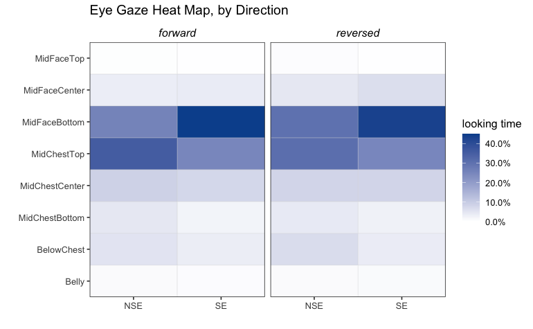

```r
heatmap_babies <- babies %>%
  filter(aoi %in% midline) %>%
  ungroup() %>%
  group_by(lang, name, direction, aoi) %>%
  summarise(percent = mean(percent, na.rm=TRUE)) %>%
  group_by(lang, direction, aoi) %>%
  summarise(percent = mean(percent, na.rm=TRUE)) %>%
  ungroup() %>%
  mutate(aoi = factor(aoi, levels = c("Belly","BelowChest","MidChestBottom","MidChestCenter","MidChestTop",
            "MidFaceBottom","MidFaceCenter","MidFaceTop")))

ggplot(heatmap_babies, aes(x = lang, y = aoi)) +
  geom_tile(aes(fill=percent),color="lightgray",na.rm=TRUE) +
#  scale_fill_viridis(option = "viridis", direction=-1, limits = c(0,.7), labels = percent, name = "looking time") +
    scale_fill_gradient(low = "#ffffff", high = "#08519c", space = "Lab", limits = c(0,.4501), labels = percent, name = "looking time", na.value = "grey50") +
  theme_bw() +
  theme(strip.text.x = element_text(size = 11, color = "black", face = "italic"),
        strip.background = element_rect(colour = "white", fill = "white"),
        panel.grid.major = element_line(color = "white")) +
  facet_grid(. ~ direction) +
  ylab("") + xlab("") + ggtitle("Eye Gaze Heat Map, by Direction") +
  scale_y_discrete(expand=c(0,0)) +
  scale_x_discrete(expand = c(0,0))
```

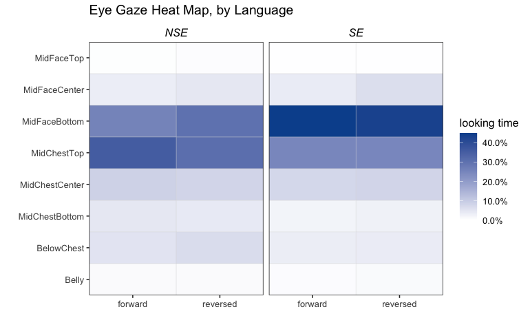

```r
ggplot(heatmap_babies, aes(x = direction, y = aoi)) +
  geom_tile(aes(fill=percent),color="lightgray",na.rm=TRUE) +
#  scale_fill_viridis(option = "viridis", direction=-1, limits = c(0,.7), labels = percent, name = "looking time") +
    scale_fill_gradient(low = "#ffffff", high = "#08519c", space = "Lab", limits = c(0,.4501), labels = percent, name = "looking time", na.value = "grey50") +
  theme_bw() +
  theme(strip.text.x = element_text(size = 11, color = "black", face = "italic"),
        strip.background = element_rect(colour = "white", fill = "white"),
        panel.grid.major = element_line(color = "white")) +
  facet_grid(. ~ lang) +
  ylab("") + xlab("") + ggtitle("Eye Gaze Heat Map, by Language") +
  scale_y_discrete(expand=c(0,0)) +
  scale_x_discrete(expand = c(0,0))
```

## Collapsed by direction (new)

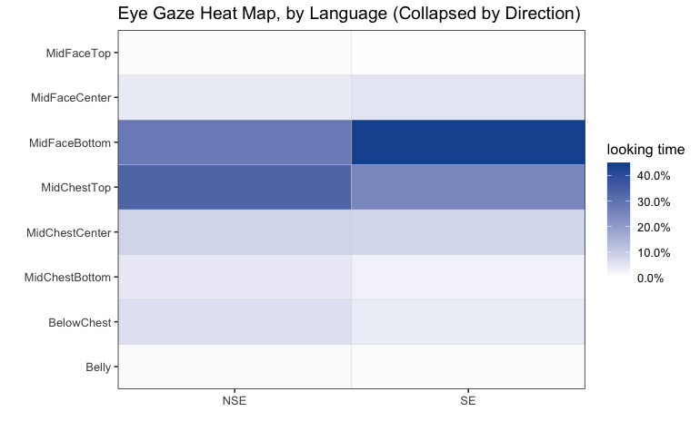

```r
heatmap_babies2 <- babies %>%
  filter(aoi %in% midline) %>%
  ungroup() %>%
  group_by(lang, name, aoi) %>%
  summarise(percent = mean(percent, na.rm=TRUE)) %>%
  group_by(lang, aoi) %>%
  summarise(percent = mean(percent, na.rm=TRUE)) %>%
  ungroup() %>%
  mutate(aoi = factor(aoi, levels = c("Belly","BelowChest","MidChestBottom","MidChestCenter","MidChestTop",
            "MidFaceBottom","MidFaceCenter","MidFaceTop")))


ggplot(heatmap_babies2, aes(x = lang, y = aoi)) +
  geom_tile(aes(fill=percent),color="lightgray",na.rm=TRUE) +
#  scale_fill_viridis(option = "viridis", direction=-1, limits = c(0,.7), labels = percent, name = "looking time") +
    scale_fill_gradient(low = "#ffffff", high = "#08519c", space = "Lab", limits = c(0,.4501), labels = percent, name = "looking time", na.value = "grey50") +
  theme_bw() +
  theme(strip.text.x = element_text(size = 11, color = "black", face = "italic"),
        strip.background = element_rect(colour = "white", fill = "white"),
        panel.grid.major = element_line(color = "white")) +
  ylab("") + xlab("") + ggtitle("Eye Gaze Heat Map, by Language (Collapsed by Direction)") +
  scale_y_discrete(expand=c(0,0)) +
  scale_x_discrete(expand = c(0,0))
```

## For poster?

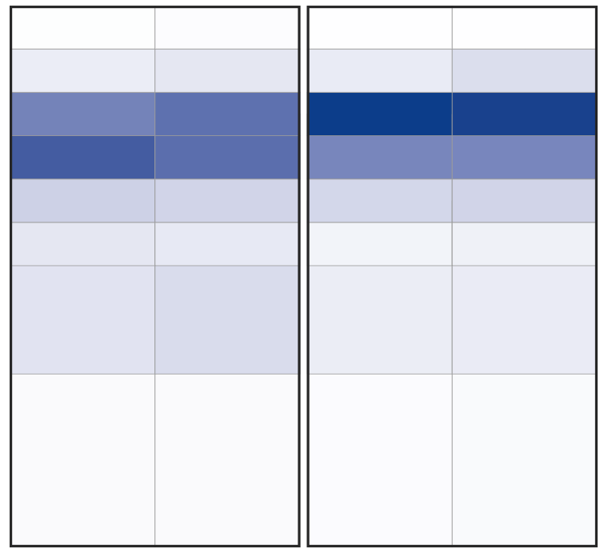

```r
ggplot(heatmap_babies, aes(x = direction, y = aoi)) +
  geom_tile(aes(fill = percent),
            color="dark gray",
            size = 0.25,
            na.rm = T,
            height = rep(c(10,4,1,1,1,1,1,1),4)) +
  scale_fill_gradient(low = "#ffffff",
                      high = "#08519c",
                      space = "Lab",
                      limits = c(0,.4501),
                      labels = percent,
                      name = "looking time",
                      na.value = "grey50") +
  facet_grid(. ~ lang) +
  ylab("") + xlab("") + ggtitle("Eye Gaze Heat Map, by Language") +
  scale_y_discrete(expand=c(0,0)) +
  scale_x_discrete(expand=c(0,0)) +
  theme_bw() +
  theme(text = element_text(size = 20, family = "xkcd"),
        axis.title.y = element_blank(),
        axis.title.x = element_blank(),
        axis.text.x = element_blank(),
        axis.text.y = element_blank(),
        axis.ticks.x = element_blank(),
        axis.ticks.y = element_blank(),
        strip.text = element_blank(),
        panel.border = element_rect(size = 2),
        title = element_blank()) +
  guides(color = FALSE, fill = FALSE)
```

# Different Ways to Visualize Reversal

I want to try to visualize reversal effects a different way. Maybe this.

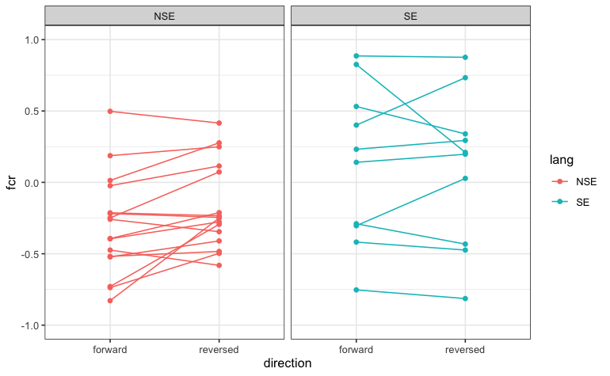

```r
# Get participant-level data
babies_fcr2 <- babies_fcr %>%
  group_by(name, age, lang, direction) %>%
  summarise(fcr = mean(fcr))

# reversal_effect_lm <- lmer(fcr ~ age + lang * direction + (1|name), data = babies_fcr2)
# summary(reversal_effect_lm)

ggplot(babies_fcr2, aes(x = direction, y = fcr, color = lang, fill = lang)) +
  geom_point() +
  geom_line(aes(group = name)) +
  facet_grid(. ~ lang) +
  scale_y_continuous(limits = c(-1,1)) +
  theme_bw()
```

Or a reversal effect chart? Okay, so this chart tells us overall there really wasn’t much of a reversal effect for SE babies, they’re all hovering around 0. Interesting. While there seems to be a reversal effect for NSE babies where they look at the face more during reversed stories!

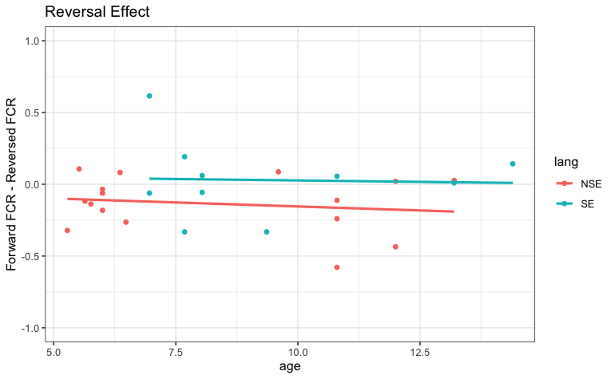

```r
# Get participant-level data
babies_fcr3 <- babies_fcr2 %>%
  spread(direction, fcr) %>%
  group_by(name, age, lang) %>%
  mutate(diff = (forward - reversed))

ggplot(babies_fcr3, aes(x = age, y = diff, color = lang)) +
  geom_point() +
  geom_smooth(method = "lm", se = FALSE) +
  scale_y_continuous(limits = c(-1,1)) +
  theme_bw() +
  ggtitle("Reversal Effect") +
  ylab("Forward FCR - Reversed FCR")
```

This analysis of within-subject variation here:

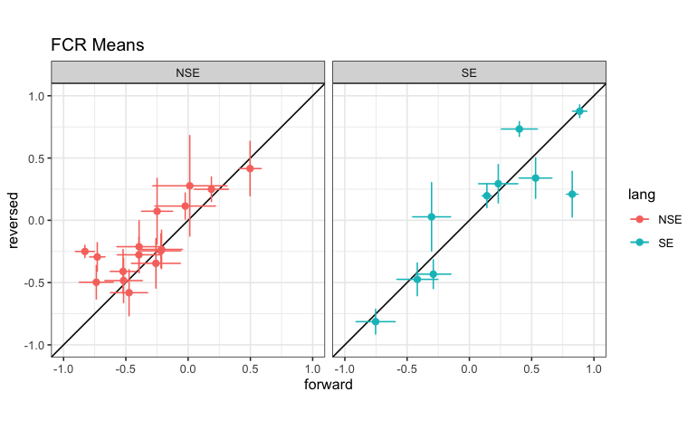

```r
# First get the mean of each trial, THEN the participant-level means
within_subjects <- babies_fcr %>%
  group_by(name, lang, direction, story, trial) %>%
  summarise(fcr = mean(fcr, na.rm = TRUE),
            count = n()) %>%
  group_by(name, lang, direction) %>%
  summarise(mean = mean(fcr, na.rm = TRUE),
            se = sd(fcr, na.rm = TRUE)/sqrt(n()),
            count = n())

# Then spread out mean and SE columns by direction
within_subjects_means <- within_subjects %>%
  select(-se, -count) %>%
  spread(direction, mean, sep = "_")
within_subjects_se <- within_subjects %>%
  select(-mean, -count) %>%
  spread(direction, se, sep = "SE")
within_subjects <- left_join(within_subjects_means, within_subjects_se, by = c("name","lang"))

# Now let's plot
lims <- c(-1,1)
within_subjects %>%
  ggplot(aes(x = direction_forward, y = direction_reversed, color = lang)) +
  geom_abline() +
  geom_point(size = 2) +
  geom_errorbar(aes(ymin=direction_reversed-directionSEreversed, ymax=direction_reversed+directionSEreversed)) +
  geom_errorbarh(aes(xmin=direction_forward-directionSEforward, xmax=direction_forward+directionSEforward)) +
  theme_bw() +
  theme(aspect.ratio = 1) +
  scale_x_continuous("forward", limits = c(-1,1)) +
  scale_y_continuous("reversed", limits = c(-1,1)) +
  ggtitle("FCR Means") +
  facet_wrap("lang")
```

And a classic box/error plot with age collapsed.

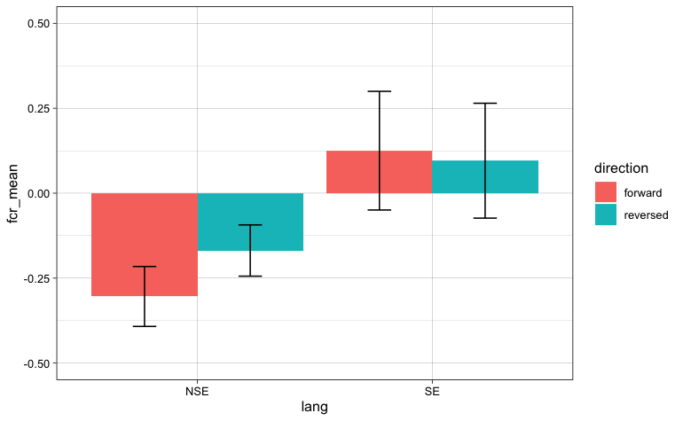

```r
babies_fcr2 %>%
  group_by(lang, direction) %>%
  summarise(fcr_mean = mean(fcr),
            sd = sd(fcr),
            n = n(),
            se = sd/sqrt(n)) %>%
  ggplot(aes(x = lang, y = fcr_mean, fill = direction)) +
  geom_bar(stat = "identity", position = position_dodge()) +
  geom_errorbar(aes(ymin = fcr_mean-se, ymax = fcr_mean+se), position = position_dodge(0.9), width = 0.2) +
  scale_y_continuous(limits = c(-0.5, 0.5)) +
  theme_linedraw()
```

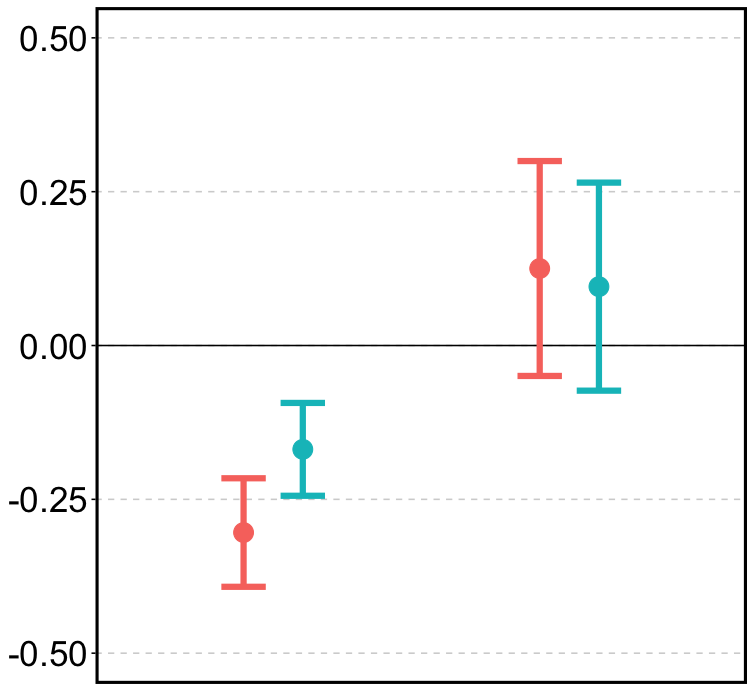

```r
library(extrafont)
library(xkcd)
# For making the babies/adults charts:
babies_fcr2 %>%
    add_column(group = 'babies') %>%
    write_csv("fcr_individual_values_babies.csv")

babies_fcr2 %>%
  group_by(lang, direction) %>%
  summarise(fcr_mean = mean(fcr),
            sd = sd(fcr),
            n = n(),
            se = sd/sqrt(n)) %>%
  add_column(group = 'babies') %>%
  write_csv("fcr_chart_babies.csv")

babies_fcr2 %>%
  group_by(lang, direction) %>%
  summarise(fcr_mean = mean(fcr),
            sd = sd(fcr),
            n = n(),
            se = sd/sqrt(n)) %>%
  ggplot(aes(x = lang, y = fcr_mean, color = direction, fill = direction, group = direction)) +
  geom_hline(yintercept = 0, size = 0.5) +
  geom_point(size = 6, position = position_dodge(width = 0.4)) +
  geom_errorbar(aes(ymin = fcr_mean-se, ymax = fcr_mean+se),
                size = 2,
                position = position_dodge(0.4),
                width = 0.3) +
  scale_y_continuous(limits = c(-0.5, 0.5)) +
  theme_linedraw() +
  theme(text = element_text(size = 30),
        panel.grid.minor.y = element_blank(),
        panel.grid.major.x = element_blank(),
        axis.title.y = element_blank(),
        axis.title.x = element_blank(),
        axis.text.x = element_blank(),
        axis.ticks.x = element_blank(),
        panel.border = element_rect(size = 2),
        axis.ticks.y = element_line(size = 0.5),
        panel.grid.major.y = element_line(size = 0.5, color = "light gray", linetype = "dashed")) +
  guides(color = FALSE, fill = FALSE)
```

# Discussion re AOI/anatomical data

The interpretation here is that:

- All babies looked equally at all videos regardless of language or direction. Good!
- SE babies are stronger face-lookers than NSE babies. (Same as ICSLA)
- Reversal appears to affect NSE babies more than SE babies? (Marginal). This is unlike ICSLA.

# XY Space Data

We’ll load the data from the `childxydata.feather` file made in 06rawxydata.Rmd. So any new babies, please run the first code block in 06 to include it. Then we’ll keep all the babies we also have in the AOI data group.

```r
included <- babies %>%
  ungroup() %>%
  select(name) %>%
  distinct() %>%
  unlist()

xydata <- read_feather("../Child Data/childxydata.feather") %>%
  rename(name = participant) %>%
  filter(name %in% included)

# Get ages
ages <- read_csv("childrenages.csv") %>%
  rename(name = participant)
xydata <- xydata %>% left_join(ages, by = "name") %>%
  mutate(age = age*12) %>%
  mutate(agegroup = case_when(
    age <= 8.99 ~ "younger",
    age >= 9.0 & age < 15 ~ "older"
  )) %>%
  mutate(language = case_when(
    language == "EnglishExposed" ~ "NSE",
    language == "SignLanguageExposed" ~ "SE"
  )) %>%
  rename(lang = language) %>%
  select(name, group, gender, lang, condition, mark, trial, repetition, x, y, age, agegroup) %>%
  separate(condition, into = c("story", "clip", "direction")) %>%
  unite("story", c("story", "clip")) %>%
  mutate(direction = case_when(
    direction == "ER" ~ "reversed",
    direction == "FW" ~ "forward"
  )) %>%
  mutate(name = factor(name),
         group = factor(group),
         gender = factor(gender),
         lang = factor(lang),
         story = factor(story),
         direction = factor(direction),
         mark = factor(mark),
         trial = factor(trial),
         repetition = factor(repetition),
         agegroup = factor(agegroup))
```

## Overall Looking

Let’s check that we have no significant group or condition differences in terms of valid (not empty) data points collected. This is same as “Global Looking” we have above, really, but w raw xy data.

```r
xy_overall <- xydata %>%
  filter(!is.na(x)) %>%
  group_by(name, age, lang, direction, story, repetition) %>%
  summarise(data_points = n()) # gets total looking percent for each trial for each baby

# Table of means
xy_overall %>%
  group_by(name, lang, direction) %>%
  summarise(data_points = mean(data_points)) %>% # get average looking percent for each baby
  group_by(lang, direction) %>%
  summarise(mean_data_points = mean(data_points),
            count = n(),
            sd = sd(data_points),
            se = sd/sqrt(count)) %>%
  select(-sd) %>%
  print()
```

| lang | direction | mean_data_points | count | se |
| --- | --- | --- | --- | --- |
| NSE | forward | 585.2400 | 16 | 50.31481 |
| NSE | reversed | 588.4868 | 16 | 57.03010 |
| SE | forward | 615.8143 | 10 | 57.15353 |
| SE | reversed | 578.4232 | 10 | 46.26341 |

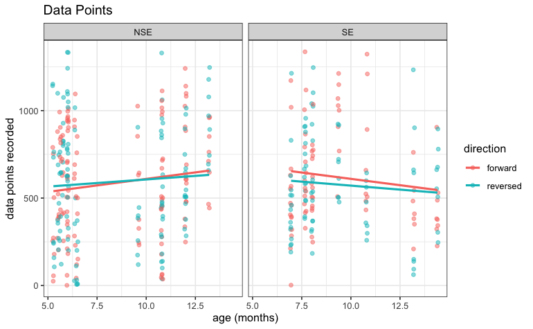

```r
ggplot(xy_overall, aes(x = age, y = data_points, color = direction, fill = direction)) +
  geom_jitter(alpha = 0.5) +
  facet_grid(. ~ lang) +
  geom_smooth(method = "lm", se = FALSE) +
  ggtitle("Data Points") +
  xlab("age (months)") +
  ylab("data points recorded") +
  theme_bw()
```

A linear model shows there were no significant effects of any factors. We can conclude there was no effect on how *much* data was collected from the babies.

```r
overall_xy_lm <- lmer(data_points ~ age + lang * direction + (direction|name) + (direction|story), data = xy_overall)
summary(overall_xy_lm)
```

```
Linear mixed model fit by REML. t-tests use Satterthwaite's method [
lmerModLmerTest]
Formula:
data_points ~ age + lang * direction + (direction | name) + (direction |
    story)
   Data: xy_overall

REML criterion at convergence: 5528.4

Scaled residuals:
    Min      1Q  Median      3Q     Max
-3.7591 -0.6647 -0.0082  0.6288  2.5534

Random effects:
 Groups   Name              Variance Std.Dev. Corr
 name     (Intercept)       20854.2  144.41
          directionreversed   800.9   28.30   1.00
 story    (Intercept)       22484.8  149.95
          directionreversed  4209.1   64.88   -0.04
 Residual                   52394.3  228.90
Number of obs: 401, groups:  name, 26; story, 8

Fixed effects:
                         Estimate Std. Error      df t value Pr(>|t|)
(Intercept)               530.672    119.943  29.510   4.424 0.000121 ***
age                         7.772     12.021  23.311   0.646 0.524272
langSE                      9.965     68.206  23.876   0.146 0.885062
directionreversed         -20.420     38.038  11.694  -0.537 0.601450
langSE:directionreversed  -16.655     48.551 134.420  -0.343 0.732113
---
Signif. codes:  0 ‘***’ 0.001 ‘**’ 0.01 ‘*’ 0.05 ‘.’ 0.1 ‘ ’ 1

Correlation of Fixed Effects:
            (Intr) age    langSE drctnr
age         -0.828
langSE      -0.057 -0.186
dirctnrvrsd -0.045 -0.003  0.065
lngSE:drctn  0.027  0.002 -0.133 -0.499
```

```r
confint(overall_xy_lm)
```

```
Computing profile confidence intervals ...
non-monotonic profile for .sig02non-monotonic profile for .sig05bad spline fit for .sig02: falling back to linear interpolationbad spline fit for .sig05: falling back to linear interpolation
```

```
                              2.5 %    97.5 %
.sig01                     94.37381 198.05145
.sig02                     -1.00000   1.00000
.sig03                      0.00000  79.33475
.sig04                     83.06418 264.23195
.sig05                     -1.00000   1.00000
.sig06                      0.00000 141.67953
.sigma                    212.91391 246.24259
(Intercept)               296.10665 769.95935
age                       -16.80438  31.72486
langSE                   -122.37062 144.10701
directionreversed         -96.43798  55.97517
langSE:directionreversed -112.38520  78.76240
```

```r
#ggcoef(overall_xy_lm)
```

## XY Data LMMs

Now we’re going to run LMMs on babies’ raw:

- horizontal spread (middle 50% of x data; xIQR)
- vertical spread (middle 50% of y data; yIQR)
- viewing area (A = middle-x * middle-y; area)

But to do this we first trim each baby’s data, getting rid of the first 60 samples (0.5 secs) of each trial.

```r
xydata <- xydata %>%
  group_by(name,trial) %>%
  slice(60:n())

iqr <- xydata %>%
  group_by(name, age, lang, story, direction, trial) %>%
  summarise(xIQR = IQR(x,na.rm=TRUE),
                   yIQR = IQR(y,na.rm=TRUE),
                   xmed = median(x, na.rm=TRUE),
                   ymed = median(y, na.rm=TRUE),
                   area = xIQR*yIQR)
head(iqr,20)
```

| name | age | lang | story | direction | trial | xIQR | yIQR | xmed | ymed | area |
| --- | --- | --- | --- | --- | --- | --- | --- | --- | --- | --- |
| AB11Mi20_5M_10D | 5.28 | NSE | Cinderella_1 | forward | 5 | 50.50 | 137.00 | 559 | 283.0 | 6918.500 |
| AB11Mi20_5M_10D | 5.28 | NSE | Cinderella_1 | forward | 13 | 367.75 | 299.75 | 515 | 397.0 | 110233.062 |
| AB11Mi20_5M_10D | 5.28 | NSE | Cinderella_2 | forward | 1 | 53.00 | 127.75 | 545 | 325.5 | 6770.750 |
| AB11Mi20_5M_10D | 5.28 | NSE | Cinderella_2 | forward | 9 | 7.25 | 19.50 | 451 | 419.0 | 141.375 |
| AB11Mi20_5M_10D | 5.28 | NSE | KingMidas_1 | reversed | 7 | 53.75 | 39.50 | 501 | 279.0 | 2123.125 |
| AB11Mi20_5M_10D | 5.28 | NSE | KingMidas_1 | reversed | 15 | 35.00 | 65.00 | 474 | 416.0 | 2275.000 |
| AB11Mi20_5M_10D | 5.28 | NSE | KingMidas_2 | reversed | 4 | 38.00 | 84.75 | 524 | 302.5 | 3220.500 |
| AB11Mi20_5M_10D | 5.28 | NSE | KingMidas_2 | reversed | 12 | 113.50 | 419.00 | 572 | 346.0 | 47556.500 |
| AB11Mi20_5M_10D | 5.28 | NSE | RedRiding_1 | forward | 2 | 86.00 | 169.00 | 526 | 317.0 | 14534.000 |
| AB11Mi20_5M_10D | 5.28 | NSE | RedRiding_1 | forward | 10 | 83.25 | 122.25 | 571 | 352.5 | 10177.312 |

[output cut: 10 more lines]

```r
NA
```

### Middle X

```r
xiqr_mean <- iqr %>%
  group_by(lang, direction, name) %>%
  summarise(xIQR = mean(xIQR, na.rm = T)) %>% # gets average looking percent for each baby
  group_by(lang, direction) %>%
  summarise(mean_xIQR = mean(xIQR), # gets group averages
            count = n(),
            sd = sd(xIQR),
            se = sd/sqrt(count)) %>%
  select(-sd) %>%
  print()
```

| lang | direction | mean_xIQR | count | se |
| --- | --- | --- | --- | --- |
| NSE | forward | 45.12305 | 16 | 3.930015 |
| NSE | reversed | 47.16443 | 16 | 4.348594 |
| SE | forward | 30.46161 | 10 | 3.111209 |
| SE | reversed | 32.41741 | 10 | 3.515805 |

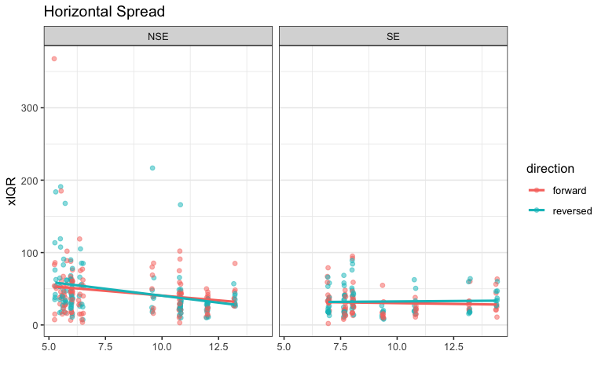

```r
# Plot
ggplot(iqr, aes(x = age, y = xIQR, color = direction, fill = direction)) +
  geom_jitter(alpha = 0.5) +
  geom_smooth(method = "lm", se = FALSE) +
  theme_bw() +
  theme(panel.grid.major.x = element_blank()) +
  facet_grid(. ~ lang) +
  ggtitle("Horizontal Spread") +
  xlab("") +
  ylab("xIQR")
```

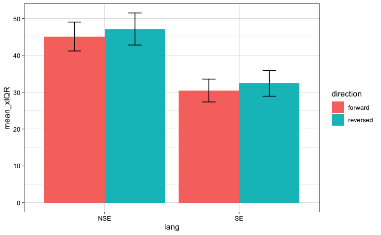

```r
ggplot(xiqr_mean, aes(x = lang, y = mean_xIQR, fill = direction)) +
  geom_bar(stat = "identity", position = position_dodge()) +
  geom_errorbar(aes(ymin = mean_xIQR-se, ymax = mean_xIQR+se), position = position_dodge(0.9), width = 0.2) +
  theme_linedraw()
```

```r
xiqr_lm <- lmer(xIQR ~ age + lang * direction + (1|name) + (1|story), data = iqr)
```

```
Model failed to converge with max|grad| = 0.00320909 (tol = 0.002, component 1)
```

```r
summary(xiqr_lm)
```

```
Linear mixed model fit by REML. t-tests use Satterthwaite's method [
lmerModLmerTest]
Formula: xIQR ~ age + lang * direction + (1 | name) + (1 | story)
   Data: iqr

REML criterion at convergence: 3839.5

Scaled residuals:
    Min      1Q  Median      3Q     Max
-2.1303 -0.4823 -0.1684  0.2619  9.8734

Random effects:
 Groups   Name        Variance Std.Dev.
 name     (Intercept) 105.6711 10.2796
 story    (Intercept)   0.4599  0.6781
 Residual             901.8340 30.0306
Number of obs: 398, groups:  name, 26; story, 8

Fixed effects:
                         Estimate Std. Error       df t value Pr(>|t|)
(Intercept)               63.1895     8.5763  25.5875   7.368 8.82e-08 ***
age                       -2.1897     0.9339  23.1557  -2.345   0.0280 *
langSE                   -12.3760     6.0882  41.4445  -2.033   0.0485 *
directionreversed          1.8858     3.8626 372.0751   0.488   0.6257
langSE:directionreversed   0.1957     6.1817 369.3450   0.032   0.9748
---
Signif. codes:  0 ‘***’ 0.001 ‘**’ 0.01 ‘*’ 0.05 ‘.’ 0.1 ‘ ’ 1

Correlation of Fixed Effects:
            (Intr) age    langSE drctnr
age         -0.901
langSE      -0.121 -0.160
dirctnrvrsd -0.214 -0.005  0.308
lngSE:drctn  0.136  0.000 -0.503 -0.625
convergence code: 0
Model failed to converge with max|grad| = 0.00320909 (tol = 0.002, component 1)
```

```r
confint(xiqr_lm)
```

[output not shown]

```
                              2.5 %     97.5 %
.sig01                     5.517731 14.3257965
.sig02                     0.000000  6.2873171
.sigma                    27.926919 32.2281330
(Intercept)               47.094920 79.2757838
age                       -3.940171 -0.4378617
langSE                   -23.852346 -0.8993574
directionreversed         -5.692211  9.4417865
langSE:directionreversed -11.912654 12.3126452
```

```r
#ggcoef(xiqr_lm)
```

### Middle Y

```r
yiqr_mean <- iqr %>%
  group_by(lang, direction, name) %>%
  summarise(yIQR = mean(yIQR, na.rm = T)) %>% # gets average looking percent for each baby
  group_by(lang, direction) %>%
  summarise(mean_yIQR = mean(yIQR), # gets group averages
            count = n(),
            sd = sd(yIQR),
            se = sd/sqrt(count)) %>%
  select(-sd) %>%
  print()
```

| lang | direction | mean_yIQR | count | se |
| --- | --- | --- | --- | --- |
| NSE | forward | 74.29381 | 16 | 8.506659 |
| NSE | reversed | 82.79511 | 16 | 10.800831 |
| SE | forward | 51.01920 | 10 | 5.831760 |
| SE | reversed | 54.22991 | 10 | 8.180136 |

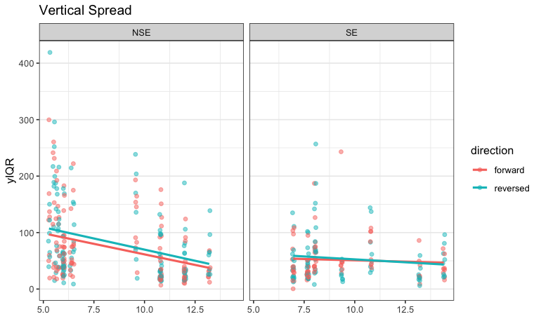

```r
# Plot
ggplot(iqr, aes(x = age, y = yIQR, color = direction, fill = direction)) +
  geom_jitter(alpha = 0.5) +
  geom_smooth(method = "lm", se = FALSE) +
  theme_bw() +
  theme(panel.grid.major.x = element_blank()) +
  facet_grid(. ~ lang) +
  ggtitle("Vertical Spread") +
  xlab("") +
  ylab("yIQR")
```

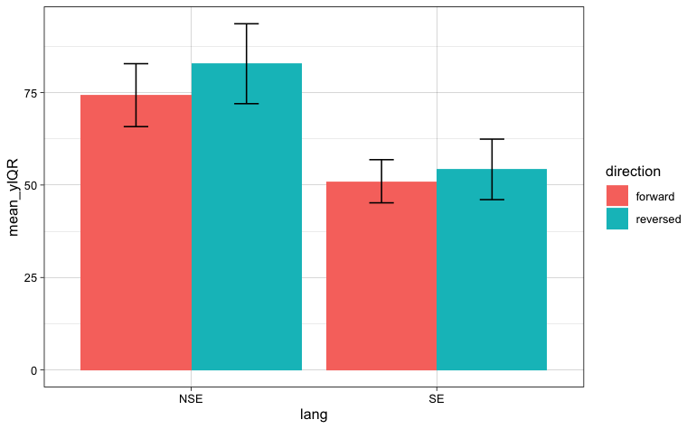

```r
ggplot(yiqr_mean, aes(x = lang, y = mean_yIQR, fill = direction)) +
  geom_bar(stat = "identity", position = position_dodge()) +
  geom_errorbar(aes(ymin = mean_yIQR-se, ymax = mean_yIQR+se), position = position_dodge(0.9), width = 0.2) +
  theme_linedraw()
```

```r
yiqr_lm <- lmer(yIQR ~ age + lang * direction + (1|name) + (1|story), data = iqr)
```

```
Model failed to converge with max|grad| = 0.00609049 (tol = 0.002, component 1)
```

```r
summary(yiqr_lm)
```

```
Linear mixed model fit by REML. t-tests use Satterthwaite's method [
lmerModLmerTest]
Formula: yIQR ~ age + lang * direction + (1 | name) + (1 | story)
   Data: iqr

REML criterion at convergence: 4251

Scaled residuals:
    Min      1Q  Median      3Q     Max
-2.7596 -0.5266 -0.2214  0.3696  5.9050

Random effects:
 Groups   Name        Variance  Std.Dev.
 name     (Intercept) 6.792e+02 26.06181
 story    (Intercept) 2.499e-04  0.01581
 Residual             2.479e+03 49.79276
Number of obs: 398, groups:  name, 26; story, 8

Fixed effects:
                         Estimate Std. Error      df t value Pr(>|t|)
(Intercept)               120.510     19.174  24.279   6.285 1.61e-06 ***
age                        -5.600      2.113  22.966  -2.650   0.0143 *
langSE                    -17.254     12.936  32.133  -1.334   0.1917
directionreversed           8.759      6.406 371.126   1.367   0.1724
langSE:directionreversed   -5.694     10.251 370.658  -0.555   0.5789
---
Signif. codes:  0 ‘***’ 0.001 ‘**’ 0.01 ‘*’ 0.05 ‘.’ 0.1 ‘ ’ 1

Correlation of Fixed Effects:
            (Intr) age    langSE drctnr
age         -0.911
langSE      -0.096 -0.171
dirctnrvrsd -0.158 -0.004  0.240
lngSE:drctn  0.101  0.000 -0.393 -0.625
convergence code: 0
Model failed to converge with max|grad| = 0.00609049 (tol = 0.002, component 1)
```

```r
confint(yiqr_lm)
```

```
Computing profile confidence intervals ...
Last two rows have identical or NA .zeta values: using minstepnon-monotonic profile for .sig02bad spline fit for .sig02: falling back to linear interpolationcollapsing to unique 'x' values
```

```
                              2.5 %     97.5 %
.sig01                    17.067513  34.481568
.sig02                     0.000000  10.380480
.sigma                    46.299351  53.445276
(Intercept)               85.144804 155.891991
age                       -9.491015  -1.709599
langSE                   -41.342020   6.860432
directionreversed         -3.780771  21.323088
langSE:directionreversed -25.806149  14.366311
```

```r
#ggcoef(yiqr_lm)
```

### Viewing Area

```r
area_mean <- iqr %>%
  group_by(lang, direction, name) %>%
  summarise(area = mean(area, na.rm = T)) %>% # gets average looking percent for each baby
  group_by(lang, direction) %>%
  summarise(area_mean = mean(area), # gets group averages
            count = n(),
            sd = sd(area),
            se = sd/sqrt(count)) %>%
  select(-sd) %>%
  print()
```

| lang | direction | area_mean | count | se |
| --- | --- | --- | --- | --- |
| NSE | forward | 4505.842 | 16 | 1100.1138 |
| NSE | reversed | 5268.891 | 16 | 1134.8780 |
| SE | forward | 1785.925 | 10 | 364.9989 |
| SE | reversed | 2196.741 | 10 | 582.3654 |

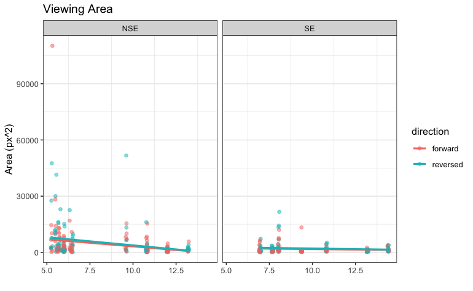

```r
# Plot
ggplot(iqr, aes(x = age, y = area, color = direction, fill = direction)) +
  geom_jitter(alpha = 0.5) +
  geom_smooth(method = "lm", se = FALSE) +
  theme_bw() +
  theme(panel.grid.major.x = element_blank()) +
  facet_grid(. ~ lang) +
  ggtitle("Viewing Area") +
  xlab("") +
  ylab("Area (px^2)")
```

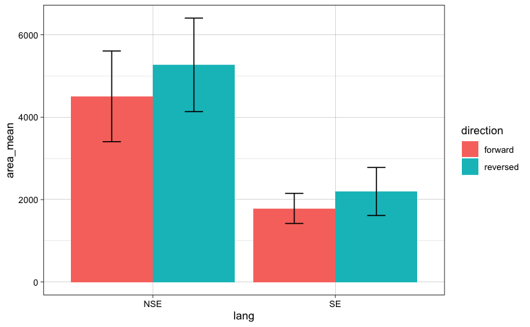

```r
ggplot(area_mean, aes(x = lang, y = area_mean, fill = direction)) +
  geom_bar(stat = "identity", position = position_dodge()) +
  geom_errorbar(aes(ymin = area_mean-se, ymax = area_mean+se), position = position_dodge(0.9), width = 0.2) +
  theme_linedraw()
```

```r
area_lm <- lmer(area ~ age + lang * direction + (1|name) + (1|story), data = iqr)
```

```
boundary (singular) fit: see ?isSingular
```

```r
summary(area_lm)
```

```
Linear mixed model fit by REML. t-tests use Satterthwaite's method [
lmerModLmerTest]
Formula: area ~ age + lang * direction + (1 | name) + (1 | story)
   Data: iqr

REML criterion at convergence: 8154.7

Scaled residuals:
    Min      1Q  Median      3Q     Max
-1.6682 -0.2747 -0.1284  0.0305 13.4651

Random effects:
 Groups   Name        Variance  Std.Dev.
 name     (Intercept) 6.314e+06 2512.8269
 story    (Intercept) 1.156e-02    0.1075
 Residual             5.292e+07 7274.7944
Number of obs: 398, groups:  name, 26; story, 8

Fixed effects:
                         Estimate Std. Error       df t value Pr(>|t|)
(Intercept)               9286.13    2088.34    25.69   4.447 0.000148 ***
age                       -577.66     227.57    23.22  -2.538 0.018291 *
langSE                   -2119.67    1481.26    41.31  -1.431 0.159954
directionreversed          708.63     935.48   372.11   0.757 0.449231
langSE:directionreversed  -299.21    1497.33   371.33  -0.200 0.841722
---
Signif. codes:  0 ‘***’ 0.001 ‘**’ 0.01 ‘*’ 0.05 ‘.’ 0.1 ‘ ’ 1

Correlation of Fixed Effects:
            (Intr) age    langSE drctnr
age         -0.901
langSE      -0.120 -0.160
dirctnrvrsd -0.213 -0.005  0.306
lngSE:drctn  0.135  0.000 -0.501 -0.625
convergence code: 0
boundary (singular) fit: see ?isSingular
```

```r
confint(area_lm)
```

```
Computing profile confidence intervals ...
```

```
                             2.5 %     97.5 %
.sig01                    1345.191  3499.1946
.sig02                       0.000  1266.8763
.sigma                    6763.421  7808.4617
(Intercept)               5290.599 13280.6501
age                      -1013.228  -141.9810
langSE                   -4950.962   711.7087
directionreversed        -1123.117  2542.6941
langSE:directionreversed -3236.019  2631.9398
```

```r
#ggcoef(area_lm)
```

## Plotting Viewing Area

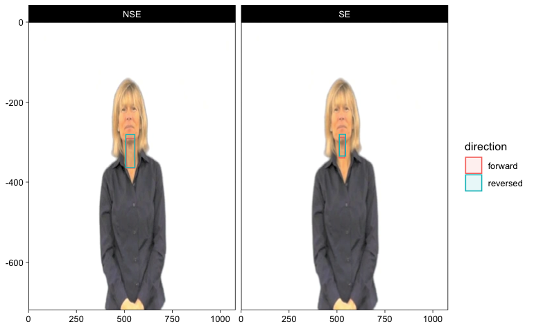

```r
medians <- iqr %>%
  group_by(name,lang,direction) %>%
  summarise(xIQR = mean(xIQR,na.rm=TRUE),
                   yIQR = mean(yIQR,na.rm=TRUE),
                   xmed = mean(xmed,na.rm=TRUE),
                   ymed = mean(ymed,na.rm=TRUE)) %>%
  group_by(lang,direction) %>%
  summarise(xIQR = mean(xIQR,na.rm=TRUE),
                   yIQR = mean(yIQR,na.rm=TRUE),
                   x = mean(xmed,na.rm=TRUE),
                   y = mean(ymed,na.rm=TRUE)) %>%
  mutate(y = y*-1,
         xmin = x-(xIQR/2),
         xmax = x+(xIQR/2),
         ymin = y-(yIQR/2),
         ymax = y+(yIQR/2))
img <- png::readPNG("cindy.png")
g <- grid::rasterGrob(img, interpolate=TRUE, width=unit(1,"npc"), height=unit(1,"npc"))
ggplot(medians, aes(fill=direction,color=direction)) +
  annotation_custom(g, xmin=-Inf, xmax=Inf, ymin=-Inf, ymax=Inf) +
  geom_rect(aes(xmin=xmin,ymin=ymin,xmax=xmax,ymax=ymax),alpha=.1) +
  theme_linedraw() +
  scale_x_continuous(limits = c(0,1080), expand = c(0, 0)) +
  scale_y_continuous(limits = c(-720,0), expand = c(0, 0)) +
  facet_wrap("lang")
```

# Puppies

Get puppy data!

```r
# puppies1 <- read_tsv("../Child Data/_puppies/all puppies group 1 sums.txt", na = "-") %>%
#   clean_names() %>%
#   select(-c(age, analysis, check_if_want_scatterplot, gender, language)) %>%
#   rename(name = x1) %>%
#   mutate(mean = rowMeans(.[2:10], na.rm = T)) %>%
#   select(name, mean)
#
# puppies2 <- read_tsv("../Child Data/_puppies/all puppies group 2 sums.txt", na = "-") %>%
#   clean_names() %>%
#   select(-c(age, analysis, check_if_want_scatterplot, gender, language)) %>%
#   rename(name = x1) %>%
#   mutate(mean = rowMeans(.[2:17], na.rm = T)) %>%
#   select(name, mean)
#
# puppies <- rbind(puppies1, puppies2)
#
# participants <- xydata %>%
#   select(name, group, gender, lang) %>%
#   distinct()
#
# puppies <- left_join(participants, puppies, by = "name")
#
# summary(lm(data = puppies, mean ~ lang))
#
# puppies_se <- filter(puppies, lang == "NSE")
# puppies_nse <- filter(puppies, lang == "SE")
#
# t.test(puppies_se$mean, puppies_nse$mean)

# Let's do this again but preserve puppy-level data
puppies1 <- read_tsv("../Child Data/_puppies/all puppies group 1 sums.txt", na = "-") %>%
  clean_names() %>%
  select(-c(age, analysis, check_if_want_scatterplot, gender, language)) %>%
  rename(name = x1) %>%
  gather(key = puppy, value = sec, -name) %>%
  mutate(pups = case_when(
    str_detect(puppy, "huskies") ~ "huskies",
    str_detect(puppy, "golden") ~ "golden",
    str_detect(puppy, "wawa") ~ "wawa",
    str_detect(puppy, "frisby") ~ "frisby",
    str_detect(puppy, "bulldog") ~ "bulldog",
    str_detect(puppy, "puppy_jpg") ~ "puppy",
    TRUE ~ puppy
  ))

puppies2 <- read_tsv("../Child Data/_puppies/all puppies group 2 sums.txt", na = "-") %>%
  clean_names() %>%
  select(-c(age, analysis, check_if_want_scatterplot, gender, language)) %>%
  rename(name = x1) %>%
  gather(key = puppy, value = sec, -name) %>%
  mutate(pups = case_when(
    str_detect(puppy, "huskies") ~ "huskies",
    str_detect(puppy, "golden") ~ "golden",
    str_detect(puppy, "wawa") ~ "wawa",
    str_detect(puppy, "frisby") ~ "frisby",
    str_detect(puppy, "bulldog") ~ "bulldog",
    str_detect(puppy, "puppies") ~ "puppies",
    TRUE ~ puppy
  ))

puppies <- rbind(puppies1,puppies2)

participants <- xydata %>%
  select(name, group, gender, lang) %>%
  distinct()

puppies <- left_join(participants, puppies, by = "name")

summary(lmer(data = puppies, sec ~ lang + (1|name) + (1|pups)))
```

```
Linear mixed model fit by REML. t-tests use Satterthwaite's method [
lmerModLmerTest]
Formula: sec ~ lang + (1 | name) + (1 | pups)
   Data: puppies

REML criterion at convergence: 15818.6

Scaled residuals:
    Min      1Q  Median      3Q     Max
-2.9738 -0.5348 -0.0747  0.3391  8.2862

Random effects:
 Groups   Name        Variance Std.Dev.
 name     (Intercept) 0.8589   0.9268
 pups     (Intercept) 0.1115   0.3339
 Residual             1.8390   1.3561
Number of obs: 4550, groups:  name, 26; pups, 7

Fixed effects:
            Estimate Std. Error      df t value Pr(>|t|)
(Intercept)   2.1716     0.2656 29.2675   8.178 4.78e-09 ***
langSE       -0.5248     0.3760 23.9275  -1.396    0.176
---
Signif. codes:  0 ‘***’ 0.001 ‘**’ 0.01 ‘*’ 0.05 ‘.’ 0.1 ‘ ’ 1

Correlation of Fixed Effects:
       (Intr)
langSE -0.545
```

```r
confint(lmer(data = puppies, sec ~ lang + (1|name) + (1|pups)))
```

```
                 2.5 %    97.5 %
.sig01       0.6940036 1.2121151
.sig02       0.1984206 0.6315016
.sigma       1.3285985 1.3845355
(Intercept)  1.6522810 2.6917220
langSE      -1.2644534 0.2148537
```

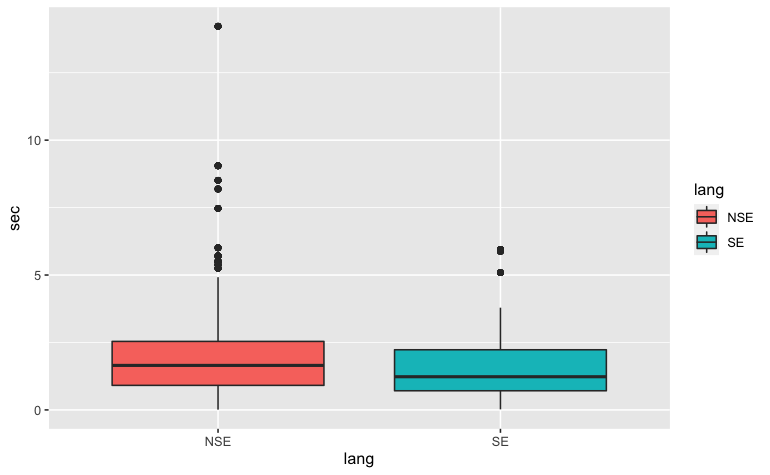

```r
ggplot(puppies, aes(x = lang, y = sec, fill = lang)) + geom_boxplot()
```

# XY Space Data - Multiple Plots

First let’s prep the data.

```r
multiples <- xydata %>%
  filter(!is.na(x)) %>%
  filter(!is.na(y)) %>%
  group_by(name, age, lang, story, direction, trial) %>%
  summarise(xIQR = IQR(x,na.rm=TRUE),
            yIQR = IQR(y,na.rm=TRUE),
            xmed = median(x, na.rm=TRUE),
            ymed = median(y, na.rm=TRUE),
            area = xIQR*yIQR,
            x_90 = quantile(x, .95, na.rm=TRUE) - quantile(x, .05, na.rm=TRUE),
            y_90 = quantile(y, .95, na.rm=TRUE) - quantile(y, .05, na.rm=TRUE),
            area_90 = (x_90) * (y_90),
            x_mean = mean(x, na.rm = TRUE),
            y_mean = mean(y, na.rm = TRUE),
            x_sd = sd(x, na.rm = TRUE),
            y_sd = sd(y, na.rm = TRUE),
            x_1sd = (x_mean+x_sd) - (x_mean-x_sd),
            y_1sd = (y_mean+y_sd) - (y_mean-y_sd),
            area_1sd = x_1sd * y_1sd,
            x_2sd = (x_mean+(x_sd*2)) - (x_mean-(x_sd*2)),
            y_2sd = (y_mean+(y_sd*2)) - (y_mean-(y_sd*2)),
            area_2sd = x_2sd * y_2sd) %>%
  group_by(name, lang, direction) %>%
  summarise_if(is.double, funs(mean), na.rm = T) %>%
  group_by(lang, direction) %>%
  summarise_if(is.double, funs(mean), na.rm = T)
```

[output not shown]

```r
img <- png::readPNG("cindy.png")
g <- grid::rasterGrob(img, interpolate=TRUE, width=unit(1,"npc"), height=unit(1,"npc"))
```

## IQR (Middle 50%)

Let’s see.

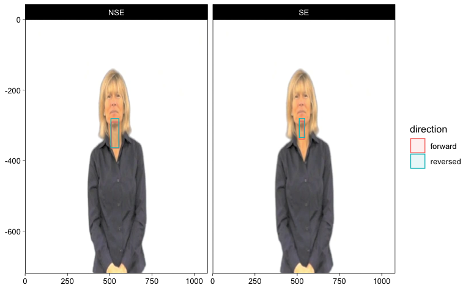

```r
curr_data <- multiples %>%
  ungroup() %>%
  select(lang, direction, xmed, ymed, xIQR, yIQR) %>%
  group_by(lang, direction) %>%
  summarise(xmin = xmed-(xIQR/2),
         xmax = xmed+(xIQR/2),
         ymin = -1*(ymed-(yIQR/2)),
         ymax = -1*(ymed+(yIQR/2)))

ggplot(curr_data, aes(fill=direction,color=direction)) +
  annotation_custom(g, xmin=-Inf, xmax=Inf, ymin=-Inf, ymax=Inf) +
  geom_rect(aes(xmin=xmin,ymin=ymin,xmax=xmax,ymax=ymax),alpha=.1) +
  theme_linedraw() +
  scale_x_continuous(limits = c(0,1080), expand = c(0, 0)) +
  scale_y_continuous(limits = c(-720,0), expand = c(0, 0)) +
  facet_wrap("lang")
```

## Middle 90%

So I calculated the average median across, and the middle 90% of the data.

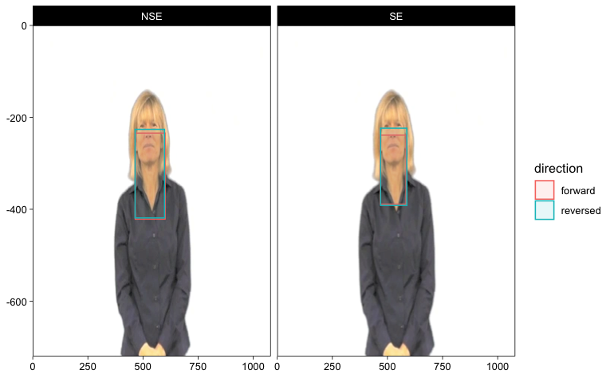

```r
curr_data <- multiples %>%
  ungroup() %>%
  select(lang, direction, xmed, ymed, x_90, y_90) %>%
  group_by(lang, direction) %>%
  summarise(xmin = xmed-(x_90/2),
         xmax = xmed+(x_90/2),
         ymin = -1*(ymed-(y_90/2)),
         ymax = -1*(ymed+(y_90/2)))

ggplot(curr_data, aes(fill=direction,color=direction)) +
  annotation_custom(g, xmin=-Inf, xmax=Inf, ymin=-Inf, ymax=Inf) +
  geom_rect(aes(xmin=xmin,ymin=ymin,xmax=xmax,ymax=ymax),alpha=.1) +
  theme_linedraw() +
  scale_x_continuous(limits = c(0,1080), expand = c(0, 0)) +
  scale_y_continuous(limits = c(-720,0), expand = c(0, 0)) +
  facet_wrap("lang")
```

```r
# ggplot(filter(curr_data, lang == "NSE"), aes(fill=direction,color=direction)) +
#   annotation_custom(g, xmin=-Inf, xmax=Inf, ymin=-Inf, ymax=Inf) +
#   geom_rect(aes(xmin=xmin,ymin=ymin,xmax=xmax,ymax=ymax),alpha=.2, size = 1) +
#   theme_linedraw() +
#   scale_x_continuous(limits = c(0,1080), expand = c(0, 0)) +
#   scale_y_continuous(limits = c(-720,0), expand = c(0, 0))
#
#
# ggplot(filter(curr_data, lang == "SE"), aes(fill=direction,color=direction)) +
#   annotation_custom(g, xmin=-Inf, xmax=Inf, ymin=-Inf, ymax=Inf) +
#   geom_rect(aes(xmin=xmin,ymin=ymin,xmax=xmax,ymax=ymax),alpha=.2, size = 1) +
#   theme_linedraw() +
#   scale_x_continuous(limits = c(0,1080), expand = c(0, 0)) +
#   scale_y_continuous(limits = c(-720,0), expand = c(0, 0))
```

## ±1 SD (Middle 68%)

So this is using the mean of the means, plus or minus one SD. This is equivalent to middle 68%.

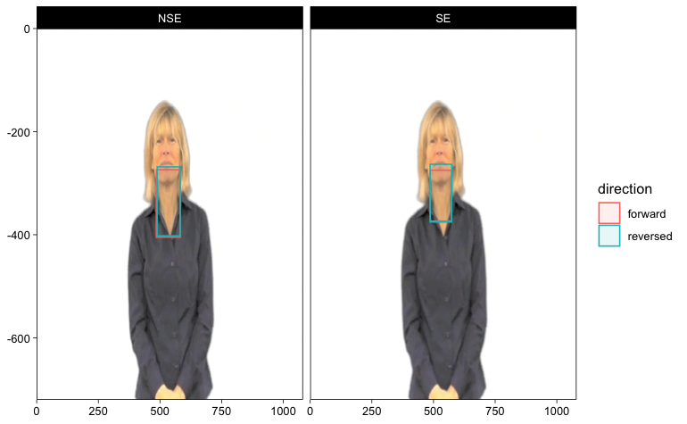

```r
curr_data <- multiples %>%
  ungroup() %>%
  select(lang, direction, x_mean, y_mean, x_1sd, y_1sd) %>%
  group_by(lang, direction) %>%
  summarise(xmin = x_mean-(x_1sd/2),
         xmax = x_mean+(x_1sd/2),
         ymin = -1*(y_mean-(y_1sd/2)),
         ymax = -1*(y_mean+(y_1sd/2)))

ggplot(curr_data, aes(fill=direction,color=direction)) +
  annotation_custom(g, xmin=-Inf, xmax=Inf, ymin=-Inf, ymax=Inf) +
  geom_rect(aes(xmin=xmin,ymin=ymin,xmax=xmax,ymax=ymax),alpha=.1) +
  theme_linedraw() +
  scale_x_continuous(limits = c(0,1080), expand = c(0, 0)) +
  scale_y_continuous(limits = c(-720,0), expand = c(0, 0)) +
  facet_wrap("lang")
```

## ±2 SD (Middle 96%)

And this is using the mean of the means, plus or minus two SD. This is equivalent to middle 96%.

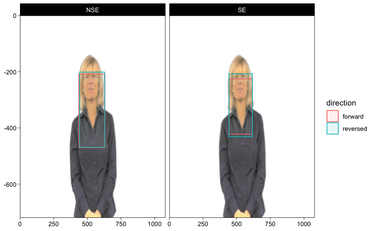

```r
curr_data <- multiples %>%
  ungroup() %>%
  select(lang, direction, x_mean, y_mean, x_2sd, y_2sd) %>%
  group_by(lang, direction) %>%
  summarise(xmin = x_mean-(x_2sd/2),
         xmax = x_mean+(x_2sd/2),
         ymin = -1*(y_mean-(y_2sd/2)),
         ymax = -1*(y_mean+(y_2sd/2)))

ggplot(curr_data, aes(fill=direction,color=direction)) +
  annotation_custom(g, xmin=-Inf, xmax=Inf, ymin=-Inf, ymax=Inf) +
  geom_rect(aes(xmin=xmin,ymin=ymin,xmax=xmax,ymax=ymax),alpha=.1) +
  theme_linedraw() +
  scale_x_continuous(limits = c(0,1080), expand = c(0, 0)) +
  scale_y_continuous(limits = c(-720,0), expand = c(0, 0)) +
  facet_wrap("lang")
```